# SGC3_A Items

*The purpose of this notebook is to analyze item-level data collected for study SGC-3: The Insight Hypothesis*

```r
#IMPORT DATA from fall and spring files
fall_items <- "data/fall_sgc3a_blocks.csv"
spring_items <- "data/spring_sgc3a_blocks.csv"
df_fall <- read.csv(fall_items)
df_spring <- read.csv(spring_items)

#Create combined data frame
df_items <- rbind(df_fall, df_spring)

#Create extra fields
df_items$time_sec <- df_items$rt / 1000 #item time in seconds

#Create answer-consistency column (desired values in column : TRI, ORTH, BOTH, NONE)
df_items$consistency = 0 #set initial dummy values
df_items <- df_items %>% mutate(consistency = replace(consistency, correct==1 & orth_correct==1, "Both"), #both
                                consistency = replace(consistency, correct==0 & orth_correct==1, "Ortho"), #orthogonal
                                consistency = replace(consistency, correct==1 & orth_correct==0, "Tri"), #triangular
                                consistency = replace(consistency, correct==0 & orth_correct==0, "Neither"), #neither
                                consistency = replace(consistency, answer=="", "BLANK")) #neither and BLANK

#Create TOTAL column for future sorting
df_totals <- df_items %>% filter(!q ==16) %>% group_by(subject)  %>% summarise(TOTAL = sum(correct))
df_items <- left_join(df_items, df_totals)

# #Code incorrect responses (not triangular or otho correct)
# df_items$response <- df_items$orth_correct + df_items$correct #items not correct in tri or orth interpretation
# df_items$response <- dplyr::recode( df_items$response, `1`= "right", `2`="both", `0`="wrong" )
# df_items$incorrect <- dplyr::recode( df_items$response, "right"=0, "both"=0, "wrong"=1 )

#Create factors
df_items <- df_items %>% mutate(
  subject = as.factor(subject),
  session = as.factor(session),
  term = as.factor(term),
  condition = as.factor(condition),
  consistency = as.factor(consistency),
  explicit = as.factor(explicit),
  impasse = as.factor(impasse),
  axis = as.factor(axis),
  q = as.factor(q),
  question = as.factor(question)
)

#Change values of column names for later reshaping
# df_items <- rename(df_items, rs_incorrect = incorrect)
df_items <- rename(df_items, rs_tri = correct)
df_items <- rename(df_items, rs_ortho = orth_correct)

#Separate free response from (main) multiple choice blocks
df_freeResponse <- df_items %>% filter(q==16)
df_items <- df_items %>% filter (q!=16)

#Cleanup temporary dataframes
rm(df_fall, df_spring, df_totals)
```

# EXPLORATION

## TIMECOURSE OF ACCURACY

I have the intuition that (for an individual participant) accurate — inaccurate responses are not randomly distributed across the timecourse of the study. There should be a substantial learning effect, such that response are incorrect — until the individual has LEARNS how the coordinate system works - and then responses will be correct.

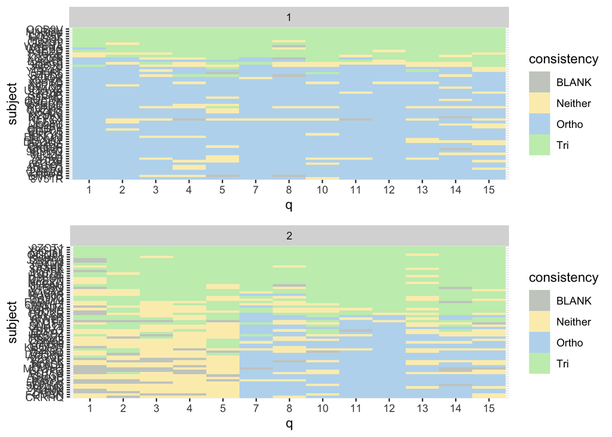

```r
#FILTER question-response data
l_timecourse <- df_items %>% filter(!q %in% c(6,9,16)) %>% #remove questions 6,9 where tri == ortho correct
  select(subject,impasse,q,consistency,TOTAL)

#ORDER dataframe by subject total amount
l_timecourse <- l_timecourse %>% mutate(subject = fct_reorder(l_timecourse$subject, l_timecourse$TOTAL, min))

#WIDE dataframe (for manual inspection)
w_timecourse <- l_timecourse %>% spread(q,consistency)

#VISUALIZE

p1 <- ggplot(l_timecourse %>% filter(impasse ==1), aes(x = q, y = subject, fill = consistency, palette = "jco")) +
  facet_grid(~ impasse) +
  geom_raster() + scale_fill_manual(values = c("#cacec8", "#FBEEBB", "#BCD9EE","#c6edbb"))

p2 <- ggplot((l_timecourse %>% filter(impasse==2)), aes(x = q, y = subject, fill = consistency)) +
  facet_grid(~ impasse) +
  geom_raster() + scale_fill_manual(values = c("#cacec8", "#FBEEBB", "#BCD9EE","#c6edbb"))

ggarrange(p1, p2, ncol=1)
```

TODO: Test this with a linear mixed effects model

## WIP RESPONSE ACCURACY

### 1.0 Response Types

```r
#SUMMARIZE by question type
df_items$dummy <- 1 #add a temporary dummy column for counting

df_questions <- df_items %>%
  filter(!q %in% c(6,9)) %>%
  group_by(q,condition) %>%
  select(q,question,rs_tri, rs_ortho, consistency, dummy) %>%
  summarize(n=n(),
            rs_tri = sum(rs_tri),
            rs_ortho = sum(rs_ortho),
            rs_blank = sum(dummy[consistency == "BLANK"]),
            rs_neither = sum(dummy[consistency == "Neither"]),
            question = question[1])
```

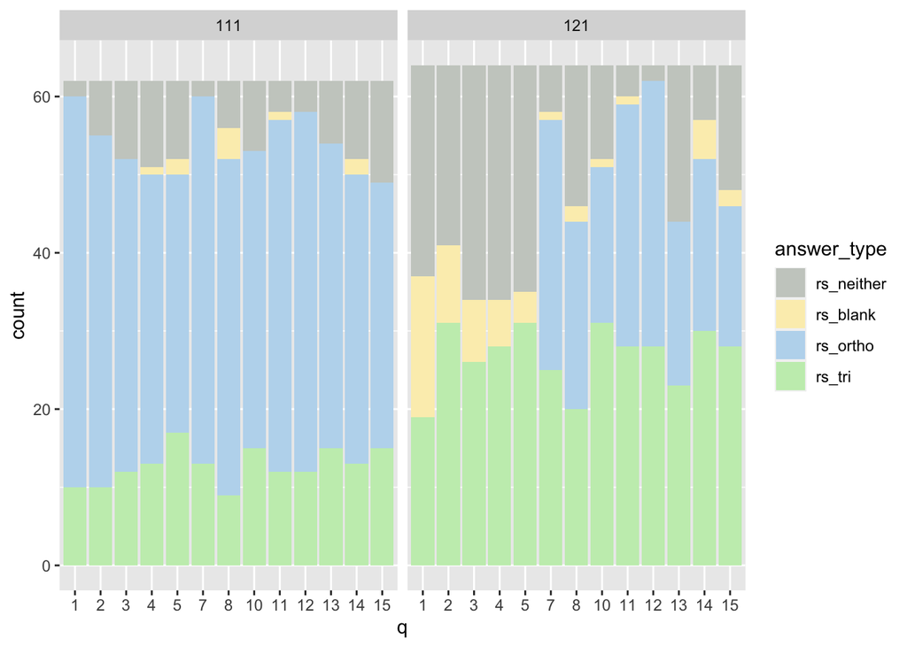

```r
#LONG dataframes
l_questions <- df_questions %>%
  pivot_longer(cols = starts_with("rs_"), names_to = "answer_type", values_to = "count")

#update factor level order in order to maximize comparison in graph
l_questions$answer_type = factor(l_questions$answer_type)
l_questions$answer_type <- relevel(l_questions$answer_type, 'rs_neither')

#TOTAL ACROSS CONDITIONS
ggplot(data = l_questions, aes (x = q, y=count, fill=answer_type))+
  geom_bar(position="stack", stat="identity") +
  facet_grid(~condition) +
  scale_fill_manual(values = c("#cacec8", "#FBEEBB", "#BCD9EE","#c6edbb"))
```

### 2.0 Question Types

TODO consider item type

## RESPONSE LATENCY

### 1.1 Distribution of Response Latency

What is the distribution of response times per question?

```r
#SUMMARIZE response time
time.stats <- favstats(~time_sec, data = df_items)
time.stats
```

```
##    min       Q1  median       Q3     max     mean       sd    n missing
##  1.264 13.80425 24.8685 46.07975 336.033 35.46849 33.11745 1890       0
```

Response time per question (n=1890) ranged from 1.2s to 336s (5.5 minutes), with a M=35.5s, SD = 33.12s.

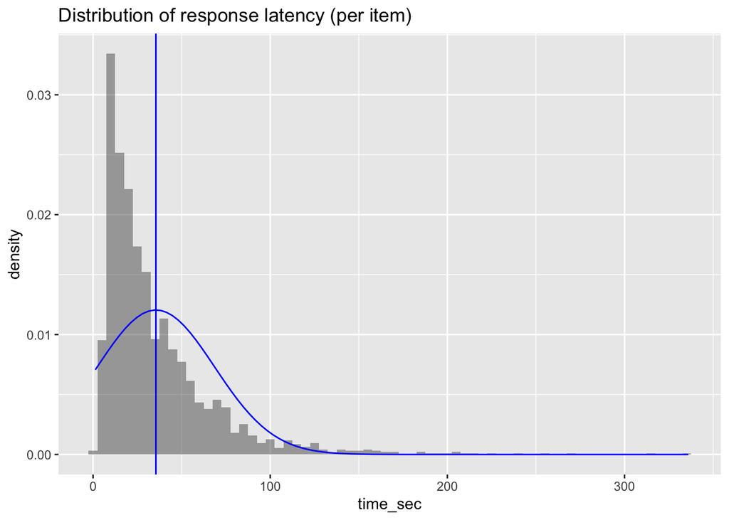

```r
#VISUALIZE distribution of response times per question
gf_dhistogram(~time_sec, binwidth = 5, data = df_items) %>%
gf_vline(xintercept = ~time.stats$mean, color = "blue") %>%
gf_fitdistr(color="blue") %>%
gf_labs(title ="Distribution of response latency (per item)")
```

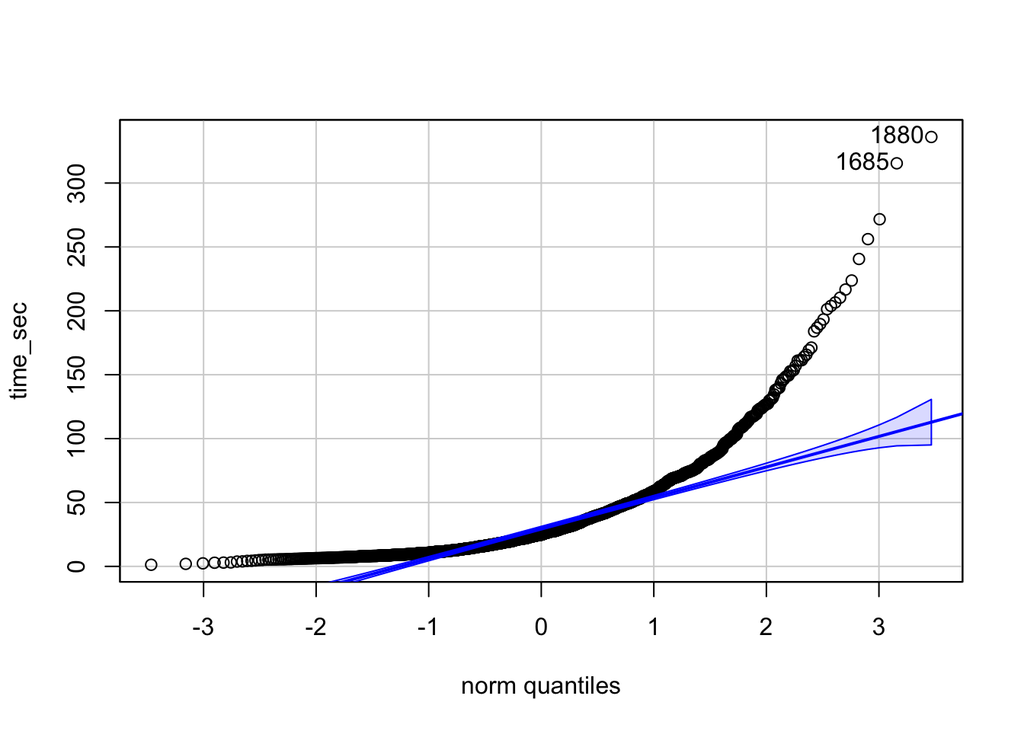

```r
#VERIFY normality of resulting data with qqPlot
qqPlot(~time_sec, data = df_items)
```

However, the distribution is clearly not normal, so it is appropriate to transform the response latency variable.

### 1.2 TRANSFORM Response Latency

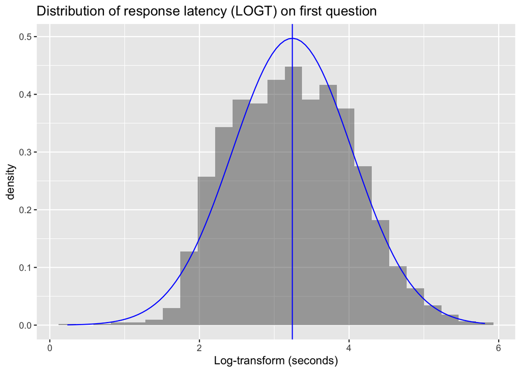

```r
#APPLY a log transform
df_items$log_time <- log(df_items$time_sec)
log_time.stats <- favstats(~log_time, data = df_items)
log_time.stats

gf_dhistogram(~log_time, data = df_items) %>%
gf_vline(xintercept = ~log_time.stats$mean, color = "blue") %>%
gf_fitdistr(color="blue") %>%
gf_labs(title ="Distribution of response latency (LOGT) on first question", x="Log-transform (seconds)")
```

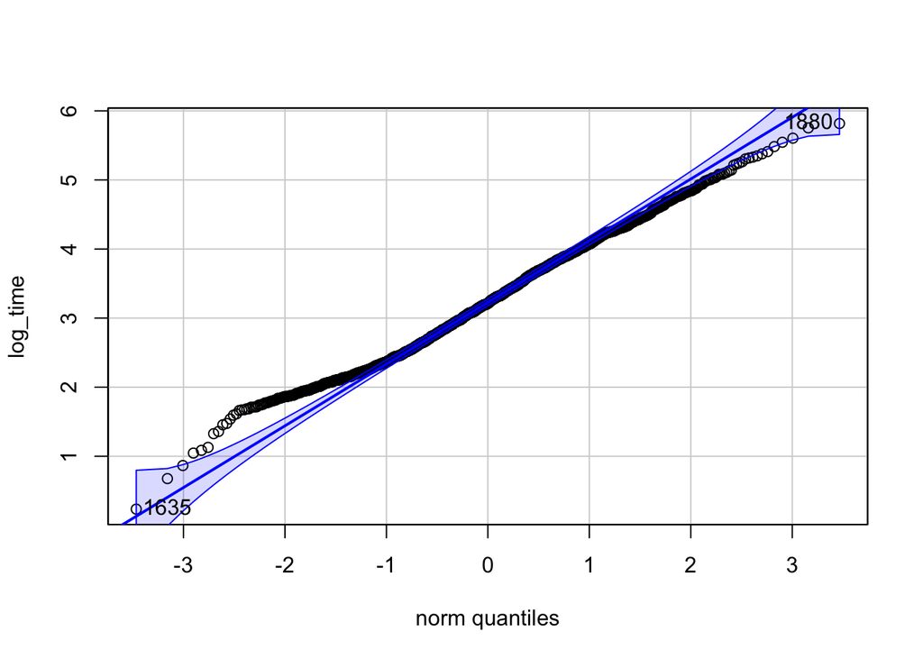

```r
#VERIFY normality of resulting data with qqPlot
qqPlot(~log_time, data = df_items)
```

TODO: Is this an appropriate outcome? What about the hump at the start of the plot?.

## FIRST QUESTION

### 1.1 Response Latency (First Question)

What is the distribution of response times on the very first question?

```r
df_q1 <- df_items %>% filter (q==1)
q1.stats <- favstats(~time_sec, data = df_q1)
q1.stats
```

```
##    min       Q1 median    Q3     max     mean       sd   n missing
##  7.223 26.61575 39.315 52.17 161.362 44.52736 26.22314 126       0
```

Response time (in seconds) on the first question (n=126) ranged from 7.2 to 161 seconds, with a M = 44.5, SD = 26.2. The distribution is clearly not-normal.

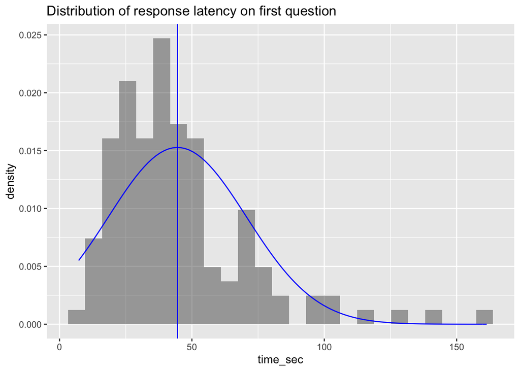

```r
gf_dhistogram(~ time_sec, data = df_q1) %>%
gf_vline(xintercept = ~q1.stats$mean, color = "blue") %>%
gf_fitdistr(color="blue") %>% # gf_dist("norm", color="blue", params=list(q1.stats$mean, q1.stats$sd), xlim(0,50)) %>%
gf_labs(title ="Distribution of response latency on first question")
```

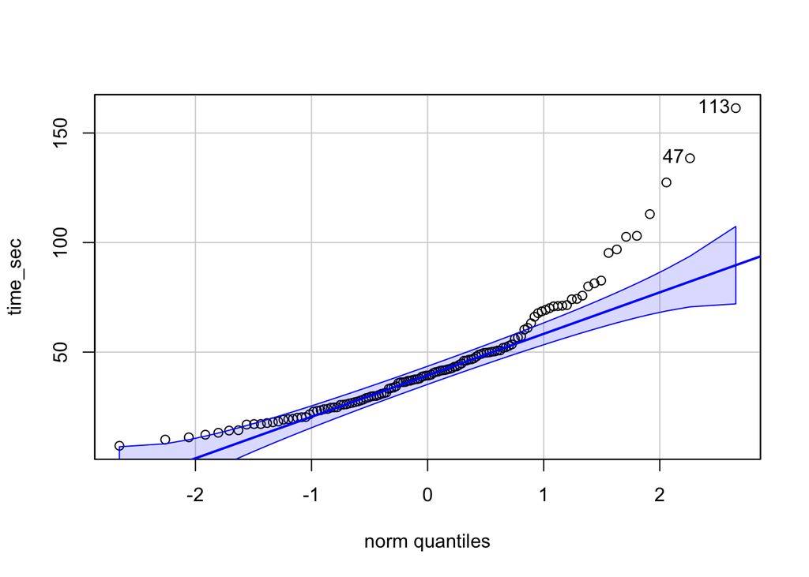

```r
#VERIFY normality of resulting data with qqPlot
qqPlot(~time_sec, data = df_q1)
```

### 1.2 Response Latency by Condition (First Question)

Do response times differ by condition? TODO: EXPLORE how to model reaction time. https://lindeloev.github.io/shiny-rt/

```r
time.stats <- favstats(time_sec ~ condition, data = df_q1)
time.stats
```

```
##   condition    min       Q1  median     Q3     max     mean       sd  n missing
## 1       111 11.080 22.94175 35.1385 43.280 112.983 37.19852 20.51576 62       0
## 2       121  7.223 32.42225 46.4050 63.909 161.362 51.62717 29.20256 64       0
```

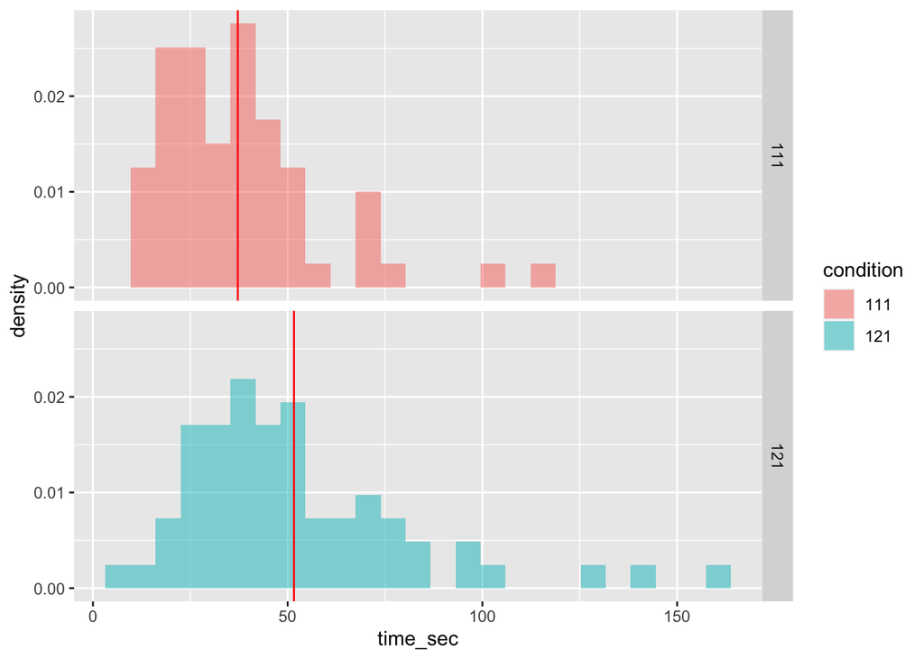

```r
gf_dhistogram(~time_sec, fill = ~condition, data = df_q1) %>%
  gf_facet_grid(condition~.) %>%
  gf_vline(xintercept = ~mean, color = "red", data = time.stats)
```

```r
time.stats <- favstats(log_time ~ condition, data = df_q1)
time.stats
```

```
##   condition      min       Q1   median       Q3      max     mean        sd  n
## 1       111 2.405142 3.132936 3.559073 3.767658 4.727237 3.483336 0.5181027 62
## 2       121 1.977270 3.477854 3.837388 4.157262 5.083650 3.797496 0.5625236 64
##   missing
## 1       0
## 2       0
```

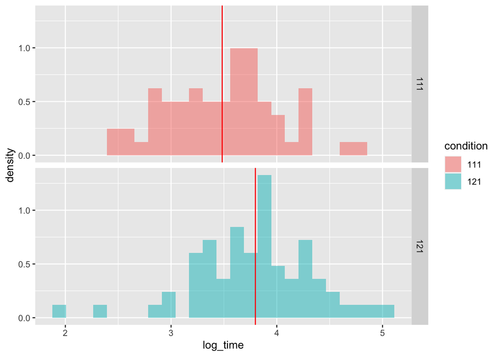

```r
gf_dhistogram(~log_time, fill = ~condition, data = df_q1) %>%
  gf_facet_grid(condition~.) %>%
  gf_vline(xintercept = ~mean, color = "red", data = time.stats)
```

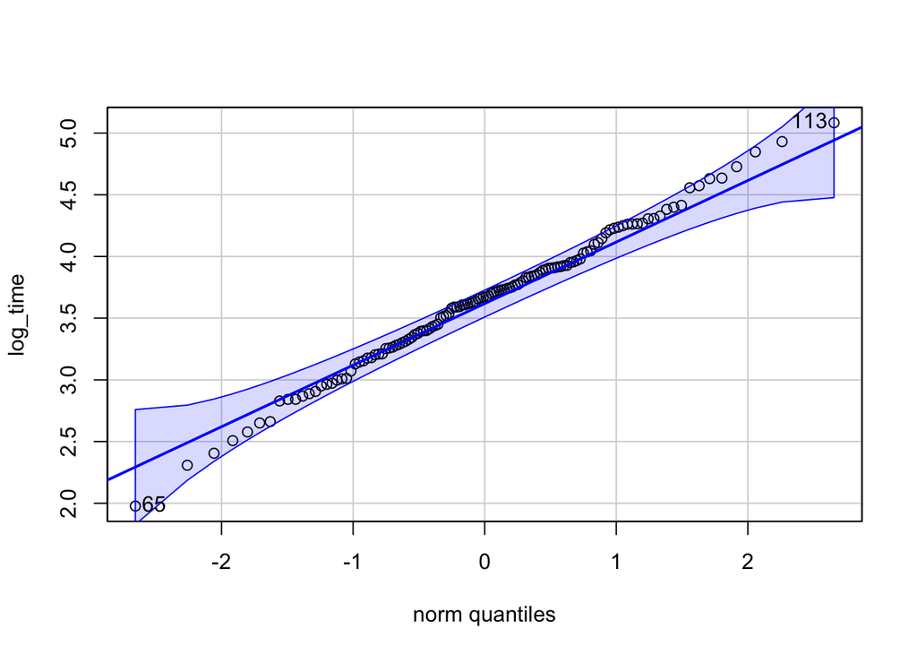

```
## [1]  65 113
```

```r
qqPlot(~log_time, data = df_q1)
```

```r
#LINEAR MODEL with dependent variable
m1 <- lm(time_sec ~ condition, data = df_q1)
summary(m1)
```

```
##
## Call:
## lm(formula = time_sec ~ condition, data = df_q1)
##
## Residuals:
##     Min      1Q  Median      3Q     Max
## -44.404 -17.456  -4.720   9.201 109.735
##
## Coefficients:
##              Estimate Std. Error t value Pr(>|t|)
## (Intercept)    37.199      3.214   11.57  < 2e-16 ***
## condition121   14.429      4.509    3.20  0.00175 **
## ---
## Signif. codes:  0 '***' 0.001 '**' 0.01 '*' 0.05 '.' 0.1 ' ' 1
##
## Residual standard error: 25.3 on 124 degrees of freedom
## Multiple R-squared:  0.07627,    Adjusted R-squared:  0.06882
## F-statistic: 10.24 on 1 and 124 DF,  p-value: 0.001746
```

```r
#LINEAR MODEL with log-transformed dependent variable
mT <- lm(log_time ~ condition, data = df_q1)
summary(mT)
```

```
##
## Call:
## lm(formula = log_time ~ condition, data = df_q1)
##
## Residuals:
##     Min      1Q  Median      3Q     Max
## -1.8202 -0.3504  0.0503  0.3382  1.2861
##
## Coefficients:
##              Estimate Std. Error t value Pr(>|t|)
## (Intercept)   3.48334    0.06872  50.686  < 2e-16 ***
## condition121  0.31416    0.09643   3.258  0.00145 **
## ---
## Signif. codes:  0 '***' 0.001 '**' 0.01 '*' 0.05 '.' 0.1 ' ' 1
##
## Residual standard error: 0.5411 on 124 degrees of freedom
## Multiple R-squared:  0.07885,    Adjusted R-squared:  0.07142
## F-statistic: 10.61 on 1 and 124 DF,  p-value: 0.001448
```

The difference in average response time (for the first question) IS statistically significant F(1,124) = 10.61 , p < 0.05, with a linear model predicting response time from condition explaining around 8% of variance. (The log-transform model reduces residual standard error from 25 to 0.5.)

# VALIDATION

## Verify item totals

First, verify (sanity check!) that the flatten.js data wrangling scripts were correct by generating participant totals directly from item-level data, and compare with participant level file. Comparison of summarized data from item_level files and participant level file show that the question accuracy totals for each participant are the same.

```r
#SUMMARIZE FROM ITEMS FILES
df_item_sanity <- df_items %>% filter(!q == 16) %>% group_by(subject) %>% summarise(
  tri_correct = sum(rs_tri),
  orth_correct = sum(rs_ortho),
  total = tri_correct + orth_correct) %>%
  mutate( subject = factor(subject)) %>%
  arrange(desc(subject))

#SUMMARIZE FROM PARTICIPANT FILES
fall_participants <- "data/fall_sgc3a_participants.csv"
spring_participants <- "data/spring_sgc3a_participants.csv"
df_fall_p <- read.csv(fall_participants)
df_spring_p <- read.csv(spring_participants)
df_participants_sanity <- rbind(df_fall_p, df_spring_p) %>%
  mutate(subject = factor(subject),
         tri_correct = triangular_score,
         orth_correct = orthogonal_score,
         total = tri_correct + orth_correct
         ) %>%
  select(subject, tri_correct, orth_correct, total) %>%
  arrange(desc(subject))

#CHECK EQUALITY
all_equal(df_participants_sanity,df_item_sanity)
```

```
## [1] TRUE
```

```r
#REMOVE TEMPORARY DFS
rm(fall_participants, spring_participants, df_participants_sanity, df_fall_p,df_spring_p)

df_items_by_participant <- df_item_sanity
rm(df_item_sanity, df_fall, df_spring)
```

## Verify session totals

How many subjects were run in each data collection session?

```r
#MANUALLY INSPECT SESSIONS
df_items %>% group_by(session) %>%
  summarize(n=length(unique(subject)))
```

```
## # A tibble: 22 × 2
##    session     n
##    <fct>   <int>
##  1 alpha       4
##  2 bravo       7
##  3 charlie    15
##  4 delta       2
##  5 echo        9
##  6 fire        5
##  7 flower      1
##  8 foxtrot     3
##  9 golf       10
## 10 heaven      3
## # … with 12 more rows
```